# AcqFac power analysis

morgan moyer

2025-08-07

# Generate fake data

Assumptions:

40 participants

8 conditions (2×2×2)

Moderate effect sizes

```r
set.seed(123)

# Factors
n_subj <- 40
n_trials <- 15  # per condition ~ must be sufficiently high for RE structure
levels_Verb <- c("know", "think")
levels_Complement <- c("that", "if")
levels_RootForce <- c("declarative", "interrogative")

# Full factorial design
design <- expand.grid(
  ID = factor(1:n_subj),
  Verb = factor(levels_Verb),
  Complement = factor(levels_Complement),
  RootForce = factor(levels_RootForce)
)

# Repeat trials per condition per participant
design <- design[rep(seq_len(nrow(design)), each = n_trials), ]

# Create Item variable: unique per condition
design$Item <- interaction(design$Verb, design$Complement, design$RootForce)

# Step 1: Simulate random intercepts for subjects
subject_rint <- rnorm(n_subj, mean = 0, sd = 0.5)
design$subject_intercept <- subject_rint[as.numeric(design$ID)]

# Step 2: Simulate random intercepts for items
item_levels <- levels(design$Item)  # ensure consistent mapping
item_rint <- rnorm(length(item_levels), mean = 0, sd = 0.3)
design$item_intercept <- item_rint[as.numeric(design$Item)]

# Step 3: Simulate fixed effects + random intercepts
design$linpred <- with(design,
  -0.2 +                            # Intercept (log-odds scale)
    0.5 * (Verb == "know") +
    0.4 * (Complement == "that") +
    0.3 * (RootForce == "declarative") +
    0.6 * (Verb == "know" & Complement == "that") +
    subject_intercept + item_intercept
)

# Step 4: Convert to binary outcome
design$choice_know <- rbinom(nrow(design), size = 1, prob = plogis(design$linpred))
```

# Fit the logit model

```r
model <- glmer(choice_know ~ Verb * Complement * RootForce +
               (1 | ID) +
               (1 | Item),
               data = design,
               family = binomial)

# Full RE model has convergence issues
# model <- glmer(choice_know ~ Verb * Complement * RootForce +
#                  (1 + Verb * Complement * RootForce|ID) +
#                  (1|Item),
#                data = design,
#                family = binomial)
```

# Power analysis

If there really is a three-way interaction in the population, how often would my model detect it as statistically significant (p < 0.05) with my sample size?

To answer that, simr uses simulation to repeatedly simulate new datasets based on your fitted model, re-fits the model on each one, and checks how often the three-way interaction is significant.

Here’s how simr works:

For each dataset:

Fits the full model (with the three-way interaction)

Fits a reduced model (without the three-way interaction)

Compares them using a likelihood ratio test

Counts how many times the p-value is < 0.05.

Returns the proportion of successful detections = estimated power.

```r
result <- powerSim(model, fixed("Verb:Complement:RootForce", "lr"), nsim = 400)
```

[output not shown]

[output not shown]

[output not shown]

[output not shown]

[output not shown]

[output not shown]

[output not shown]

[output not shown]

[output not shown]

[output not shown]

[output not shown]

[output not shown]

[output not shown]

[output not shown]

[output not shown]

[output not shown]

[output not shown]

[output not shown]

[output not shown]

[output not shown]

[output not shown]

[output not shown]

[output not shown]

[output not shown]

[output not shown]

[output not shown]

[output not shown]

[output not shown]

[output not shown]

[output not shown]

[output not shown]

[output not shown]

[output not shown]

[output not shown]

[output not shown]

[output not shown]

[output not shown]

[output not shown]

[output not shown]

[output not shown]

[output not shown]

[output not shown]

[output not shown]

[output not shown]

[output not shown]

[output not shown]

[output not shown]

[output not shown]

[output not shown]

[output not shown]

[output not shown]

[output not shown]

[output not shown]

[output not shown]

[output not shown]

[output not shown]

[output not shown]

[output not shown]

[output not shown]

[output not shown]

[output not shown]

[output not shown]

[output not shown]

[output not shown]

[output not shown]

[output not shown]

[output not shown]

```r
saveRDS(result, "powerSim_output.rds")
result
```

```
## Power for predictor 'Verb:Complement:RootForce', (95% confidence interval):
##       11.25% ( 8.33, 14.76)
##
## Test: Likelihood ratio
##
## Based on 400 simulations, (108 warnings, 0 errors)
## alpha = 0.05, nrow = 4800
##
## Time elapsed: 0 h 34 m 15 s
##
## nb: result might be an observed power calculation
```

# Estimate sample size

```r
# Extend model for more participants
model_extended <- extend(model, along = "ID", n = 500)
saveRDS(model_extended, "model_extended_output.rds")
model_extended
```

```
## Generalized linear mixed model fit by maximum likelihood (Laplace
##   Approximation) [glmerMod]
##  Family: binomial  ( logit )
## Formula: choice_know ~ Verb * Complement * RootForce + (1 | ID) + (1 |
##     Item)
##    Data: design
##       AIC       BIC    logLik  deviance  df.resid
##  5911.006  5975.770 -2945.503  5891.006      4790
## Random effects:
##  Groups Name        Std.Dev.
##  ID     (Intercept) 0.4315
##  Item   (Intercept) 0.0000
## Number of obs: 4800, groups:  ID, 40; Item, 8
## Fixed Effects:
##                                     (Intercept)
##                                          0.3712
##                                       Verbthink
##                                         -0.2825
##                                  Complementthat
##                                          0.8954
##                          RootForceinterrogative
##                                          0.2734
##                        Verbthink:Complementthat
##                                          0.3726
##                Verbthink:RootForceinterrogative
##                                         -0.9267
##           Complementthat:RootForceinterrogative
##                                         -0.5046
## Verbthink:Complementthat:RootForceinterrogative
##                                         -0.1729
## optimizer (Nelder_Mead) convergence code: 0 (OK) ; 0 optimizer warnings; 1 lme4 warnings
```

```r
# Power curve for 3-way interaction
pc <- powerCurve(model_extended, fixed("Verb:Complement:RootForce", "lr"), along = "ID", nsim = 50)
```

[output not shown]

[output not shown]

[output not shown]

[output not shown]

[output not shown]

[output not shown]

[output not shown]

[output not shown]

[output not shown]

[output not shown]

[output not shown]

[output not shown]

[output not shown]

[output not shown]

[output not shown]

[output not shown]

[output not shown]

[output not shown]

[output not shown]

[output not shown]

[output not shown]

[output not shown]

[output not shown]

[output not shown]

[output not shown]

[output not shown]

[output not shown]

[output not shown]

[output not shown]

[output not shown]

[output not shown]

[output not shown]

[output not shown]

[output not shown]

[output not shown]

[output not shown]

[output not shown]

[output not shown]

[output not shown]

[output not shown]

[output not shown]

[output not shown]

[output not shown]

[output not shown]

[output not shown]

[output not shown]

[output not shown]

[output not shown]

[output not shown]

[output not shown]

[output not shown]

[output not shown]

[output not shown]

[output not shown]

[output not shown]

[output not shown]

[output not shown]

[output not shown]

[output not shown]

[output not shown]

[output not shown]

[output not shown]

[output not shown]

[output not shown]

[output not shown]

[output not shown]

[output not shown]

[output not shown]

[output not shown]

[output not shown]

[output not shown]

[output not shown]

[output not shown]

[output not shown]

[output not shown]

[output not shown]

[output not shown]

[output not shown]

[output not shown]

[output not shown]

[output not shown]

[output not shown]

[output not shown]

[output not shown]

[output not shown]

[output not shown]

[output not shown]

[output not shown]

[output not shown]

[output not shown]

[output not shown]

[output not shown]

[output not shown]

[output not shown]

[output not shown]

[output not shown]

[output not shown]

[output not shown]

[output not shown]

[output not shown]

[output not shown]

[output not shown]

[output not shown]

[output not shown]

[output not shown]

[output not shown]

[output not shown]

[output not shown]

[output not shown]

[output not shown]

[output not shown]

[output not shown]

[output not shown]

[output not shown]

[output not shown]

[output not shown]

[output not shown]

[output not shown]

[output not shown]

[output not shown]

[output not shown]

[output not shown]

[output not shown]

[output not shown]

[output not shown]

[output not shown]

[output not shown]

[output not shown]

[output not shown]

[output not shown]

[output not shown]

[output not shown]

[output not shown]

[output not shown]

[output not shown]

[output not shown]

[output not shown]

[output not shown]

[output not shown]

[output not shown]

[output not shown]

[output not shown]

[output not shown]

[output not shown]

[output not shown]

[output not shown]

[output not shown]

[output not shown]

[output not shown]

[output not shown]

[output not shown]

[output not shown]

[output not shown]

[output not shown]

[output not shown]

[output not shown]

[output not shown]

[output not shown]

[output not shown]

[output not shown]

[output not shown]

[output not shown]

[output not shown]

[output not shown]

[output not shown]

[output not shown]

[output not shown]

[output not shown]

[output not shown]

[output not shown]

[output not shown]

[output not shown]

[output not shown]

[output not shown]

[output not shown]

[output not shown]

[output not shown]

[output not shown]

[output not shown]

[output not shown]

[output not shown]

[output not shown]

[output not shown]

[output not shown]

[output not shown]

[output not shown]

[output not shown]

[output not shown]

[output not shown]

[output not shown]

[output not shown]

[output not shown]

[output not shown]

[output not shown]

[output not shown]

[output not shown]

[output not shown]

[output not shown]

[output not shown]

[output not shown]

[output not shown]

[output not shown]

[output not shown]

[output not shown]

[output not shown]

[output not shown]

[output not shown]

[output not shown]

[output not shown]

[output not shown]

[output not shown]

[output not shown]

[output not shown]

[output not shown]

[output not shown]

[output not shown]

[output not shown]

[output not shown]

[output not shown]

[output not shown]

[output not shown]

[output not shown]

[output not shown]

[output not shown]

[output not shown]

[output not shown]

[output not shown]

[output not shown]

[output not shown]

[output not shown]

[output not shown]

[output not shown]

[output not shown]

[output not shown]

[output not shown]

[output not shown]

[output not shown]

[output not shown]

[output not shown]

[output not shown]

[output not shown]

[output not shown]

[output not shown]

[output not shown]

[output not shown]

[output not shown]

[output not shown]

[output not shown]

[output not shown]

[output not shown]

[output not shown]

[output not shown]

[output not shown]

[output not shown]

[output not shown]

[output not shown]

[output not shown]

[output not shown]

[output not shown]

[output not shown]

[output not shown]

[output not shown]

[output not shown]

[output not shown]

[output not shown]

[output not shown]

[output not shown]

[output not shown]

[output not shown]

[output not shown]

[output not shown]

[output not shown]

[output not shown]

[output not shown]

[output not shown]

[output not shown]

[output not shown]

[output not shown]

[output not shown]

[output not shown]

[output not shown]

[output not shown]

[output not shown]

[output not shown]

[output not shown]

[output not shown]

[output not shown]

[output not shown]

[output not shown]

[output not shown]

[output not shown]

[output not shown]

[output not shown]

[output not shown]

[output not shown]

[output not shown]

[output not shown]

[output not shown]

[output not shown]

[output not shown]

[output not shown]

[output not shown]

[output not shown]

[output not shown]

[output not shown]

[output not shown]

[output not shown]

[output not shown]

[output not shown]

[output not shown]

[output not shown]

[output not shown]

[output not shown]

[output not shown]

[output not shown]

[output not shown]

[output not shown]

[output not shown]

[output not shown]

[output not shown]

[output not shown]

[output not shown]

[output not shown]

[output not shown]

[output not shown]

[output not shown]

[output not shown]

[output not shown]

[output not shown]

[output not shown]

[output not shown]

[output not shown]

[output not shown]

[output not shown]

[output not shown]

[output not shown]

[output not shown]

[output not shown]

[output not shown]

[output not shown]

[output not shown]

[output not shown]

[output not shown]

[output not shown]

[output not shown]

[output not shown]

[output not shown]

[output not shown]

[output not shown]

[output not shown]

[output not shown]

[output not shown]

[output not shown]

[output not shown]

[output not shown]

[output not shown]

[output not shown]

[output not shown]

[output not shown]

[output not shown]

[output not shown]

[output not shown]

[output not shown]

[output not shown]

[output not shown]

[output not shown]

[output not shown]

[output not shown]

[output not shown]

[output not shown]

[output not shown]

[output not shown]

[output not shown]

[output not shown]

[output not shown]

[output not shown]

[output not shown]

[output not shown]

[output not shown]

[output not shown]

[output not shown]

[output not shown]

[output not shown]

[output not shown]

[output not shown]

[output not shown]

[output not shown]

[output not shown]

[output not shown]

[output not shown]

[output not shown]

[output not shown]

[output not shown]

[output not shown]

[output not shown]

[output not shown]

[output not shown]

[output not shown]

[output not shown]

[output not shown]

[output not shown]

[output not shown]

[output not shown]

[output not shown]

[output not shown]

[output not shown]

[output not shown]

[output not shown]

[output not shown]

[output not shown]

[output not shown]

[output not shown]

[output not shown]

[output not shown]

[output not shown]

[output not shown]

[output not shown]

[output not shown]

[output not shown]

[output not shown]

[output not shown]

[output not shown]

[output not shown]

[output not shown]

[output not shown]

[output not shown]

[output not shown]

[output not shown]

[output not shown]

[output not shown]

[output not shown]

[output not shown]

[output not shown]

[output not shown]

[output not shown]

[output not shown]

[output not shown]

[output not shown]

[output not shown]

[output not shown]

[output not shown]

[output not shown]

[output not shown]

[output not shown]

[output not shown]

[output not shown]

[output not shown]

[output not shown]

[output not shown]

[output not shown]

[output not shown]

[output not shown]

[output not shown]

[output not shown]

[output not shown]

[output not shown]

[output not shown]

[output not shown]

[output not shown]

[output not shown]

[output not shown]

[output not shown]

[output not shown]

[output not shown]

[output not shown]

[output not shown]

[output not shown]

[output not shown]

[output not shown]

[output not shown]

[output not shown]

[output not shown]

[output not shown]

[output not shown]

[output not shown]

[output not shown]

[output not shown]

[output not shown]

[output not shown]

[output not shown]

[output not shown]

[output not shown]

[output not shown]

[output not shown]

[output not shown]

[output not shown]

[output not shown]

[output not shown]

[output not shown]

[output not shown]

[output not shown]

[output not shown]

[output not shown]

[output not shown]

[output not shown]

[output not shown]

[output not shown]

[output not shown]

[output not shown]

[output not shown]

[output not shown]

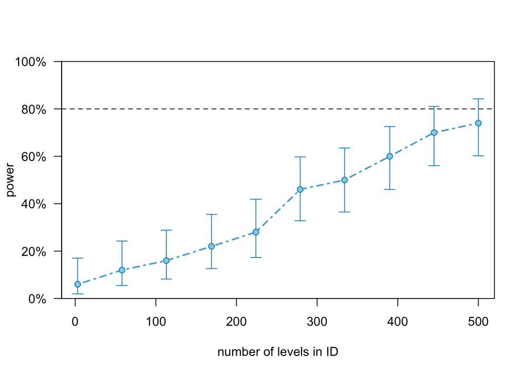

```r
plot(pc)
```